# yunhuaz_Titis

## Favorite Titi Image

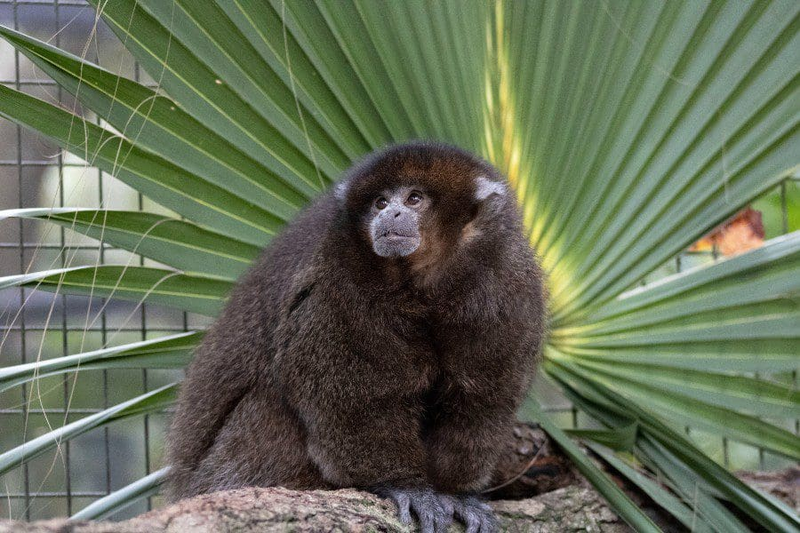

## What is the probability that she will hear more than 8 calls during any given sessions?

```r
#Mean number of calls
l <- 15

#Probability its greater than 8
p_greater_than_8 <- 1 - ppois(8, lambda = l, lower.tail = TRUE)

p_greater_than_8
```

```
## [1] 0.9625535
```

## What is the probability that she will hear no calls in a session?

```r
#Mean number of calls
l <- 15

#Probability of no calls
p_no_calls <- dpois(0, lambda = l)

p_no_calls
```

```
## [1] 3.059023e-07
```

The dpois() function is used in this question since it helps us calculate the probability mass function (PMF) of the Poisson distribution, which gives the probability of exactly *k* occurrences for an event. Which in this event we are trying to find the probability for the exact number of times where they won’t call.

## What is the probability she will hear exactly 3 calls in a session?

```r
#Mean number of calls
l <- 15

#Probabiltiy of exactly 3 calls
p_3_calls <- dpois(3, lambda = l)

p_3_calls
```

```
## [1] 0.0001720701
```

Similarly, to last questions explanation we are trying to determine the probability for exact number of occurrences (*k*) which is 3. What is the probability that she will here exactly 3 calls, therefore we will be using the function dpois().

## Plot the relevant Poisson mass function over the values in range 0 ≤ x ≤ 30.

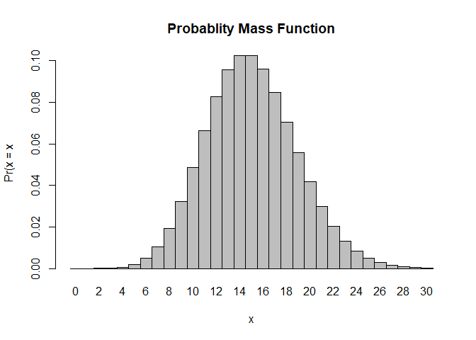

```r
x <- 0:30
l <- 15

probset <- dpois(x = x, lambda = l)
#Use Histogram
barplot(probset, names.arg = x, space = 0, xlab = "x", ylab = "Pr(x = x", main = "Probablity Mass Function")
```

## Simulate 104 results from this distribution (i.e., 2 years of Saturday morning sessions. Plot the simulated results using hist() and use xlim() to set the horizontal limits to be from 0 to 30. How does your histogram compare to the shape of the probability mass function you plotted above?

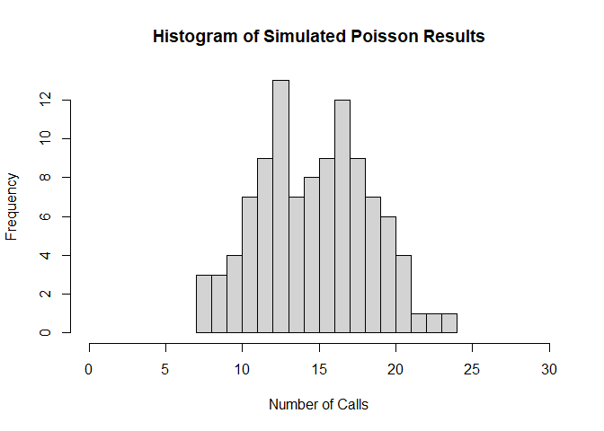

```r
set.seed(1)
sim_results <- rpois(n = 104, lambda = 15)

hist(sim_results, breaks = 15, xlab = "Number of Calls", ylab = "Frequency", main = "Histogram of Simulated Poisson Results", xlim = c(0,30))
```

Specifying a seed when generating a random sample allows for the same “random” sample every time we run that cell. This ensures reproducibility in this code, I specified the seed to be one ensure that I receive the same sample of size 104 from a Poisson(15) distribution. The histogram I plotted for the given seed displayed a bimodal shaped distribution, and the probability mass function exhibits a bell curve. Overall, based on the tails if we were to generate more samples we are able to create a similar shape to the probability mass function.

## Issues

Issues I ran into were trying to determine when it was appropriate to use a certain function (dpois(), ppois(), and rpois()). Overall, once I grasp the understanding of these functions I was able to implement them into my code which then assisted me in answering the questions.

I also struggled in trying to use the prettydoc package with the theme since I was quarto instead of R markdown. As a solution I download the file as an Rmd file and try to knit it then.